# Decision Trees Classifier - Cars Dataset

Data Science Analysis

2025-09-10

# Introduction

This analysis demonstrates Decision Tree classification using the Cars Evaluation Dataset. Decision Trees are one of the most popular machine learning algorithms that use a tree-like structure to solve classification problems. They belong to the class of supervised learning algorithms and can be used for both classification and regression purposes.

## Objectives

- Implement Decision Tree classifiers with different criteria (Gini and Information Gain)
- Perform exploratory data analysis on the cars dataset
- Evaluate model performance using various metrics
- Visualize decision trees and feature importance
- Compare the performance of different splitting criteria

# Dataset Overview

The Car Evaluation Database contains examples with structural information about car characteristics and their acceptability ratings. The dataset includes 1728 instances with 7 variables.

## Attribute Information

- **buying**: buying price (vhigh, high, med, low)
- **maint**: price of the maintenance (vhigh, high, med, low)
- **doors**: number of doors (2, 3, 4, 5more)
- **persons**: capacity in terms of persons to carry (2, 4, more)
- **lug_boot**: the size of luggage boot (small, med, big)
- **safety**: estimated safety of the car (low, med, high)
- **class**: car acceptability (unacc, acc, good, vgood)

```r
# Load required packages
library(rpart)        # For Decision Trees
library(rpart.plot)   # For plotting decision trees
library(caret)        # For data splitting and confusion matrix
library(ggplot2)      # For plotting
library(dplyr)        # For data manipulation
library(corrplot)     # For correlation matrix visualization
library(gridExtra)    # For arranging multiple plots
library(pROC)         # For ROC curve
library(tidyr)        # For pivot_longer

# Set seed for reproducibility
set.seed(123)
```

```r
# Load the cars dataset
cars_data <- read.csv("Cars-Dataset/cars.csv", header = FALSE, stringsAsFactors = FALSE)

# Set column names
col_names <- c('buying', 'maint', 'doors', 'persons', 'lug_boot', 'safety', 'class')
colnames(cars_data) <- col_names

# Convert all columns to factors since they are categorical
cars_data[] <- lapply(cars_data, factor)

# Display basic information
cat("Dataset dimensions:", dim(cars_data), "\n")
```

```
## Dataset dimensions: 1728 7
```

```r
cat("Column names:", paste(col_names, collapse = ", "), "\n")
```

```
## Column names: buying, maint, doors, persons, lug_boot, safety, class
```

```r
# Preview the dataset
head(cars_data, 10)
```

```
##    buying maint doors persons lug_boot safety class
## 1   vhigh vhigh     2       2    small    low unacc
## 2   vhigh vhigh     2       2    small    med unacc
## 3   vhigh vhigh     2       2    small   high unacc
## 4   vhigh vhigh     2       2      med    low unacc
## 5   vhigh vhigh     2       2      med    med unacc
## 6   vhigh vhigh     2       2      med   high unacc
## 7   vhigh vhigh     2       2      big    low unacc
## 8   vhigh vhigh     2       2      big    med unacc
## 9   vhigh vhigh     2       2      big   high unacc
## 10  vhigh vhigh     2       4    small    low unacc
```

```r
# Summary of the dataset
str(cars_data)
```

```
## 'data.frame':    1728 obs. of  7 variables:
##  $ buying  : Factor w/ 4 levels "high","low","med",..: 4 4 4 4 4 4 4 4 4 4 ...
##  $ maint   : Factor w/ 4 levels "high","low","med",..: 4 4 4 4 4 4 4 4 4 4 ...
##  $ doors   : Factor w/ 4 levels "2","3","4","5more": 1 1 1 1 1 1 1 1 1 1 ...
##  $ persons : Factor w/ 3 levels "2","4","more": 1 1 1 1 1 1 1 1 1 2 ...
##  $ lug_boot: Factor w/ 3 levels "big","med","small": 3 3 3 2 2 2 1 1 1 3 ...
##  $ safety  : Factor w/ 3 levels "high","low","med": 2 3 1 2 3 1 2 3 1 2 ...
##  $ class   : Factor w/ 4 levels "acc","good","unacc",..: 3 3 3 3 3 3 3 3 3 3 ...
```

# Exploratory Data Analysis

## Class Distribution

```r
# Class distribution
class_counts <- table(cars_data$class)
print(class_counts)
```

```
##
##   acc  good unacc vgood
##   384    69  1210    65
```

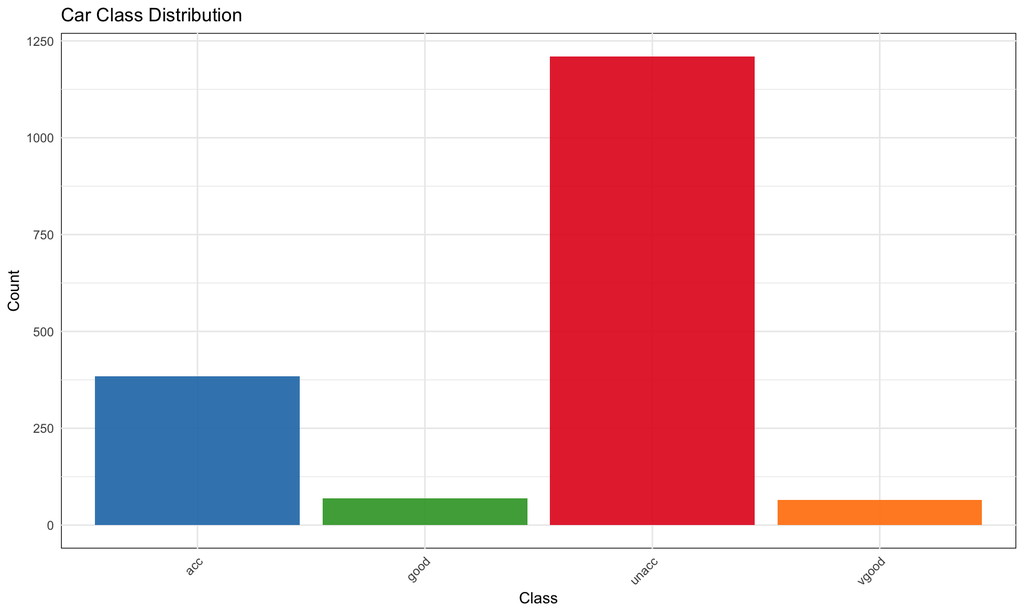

```r
# Visualize class distribution
ggplot(cars_data, aes(x = class, fill = class)) +
  geom_bar(alpha = 0.9) +
  scale_fill_manual(values = c("unacc" = "#e31a1c", "acc" = "#1f78b4",
                              "good" = "#33a02c", "vgood" = "#ff7f00")) +
  labs(title = "Car Class Distribution", x = "Class", y = "Count") +
  theme_minimal() +
  theme(panel.background = element_rect(fill = "white"),
        axis.text.x = element_text(angle = 45, hjust = 1),
        legend.position = "none")
```

## Feature Distributions

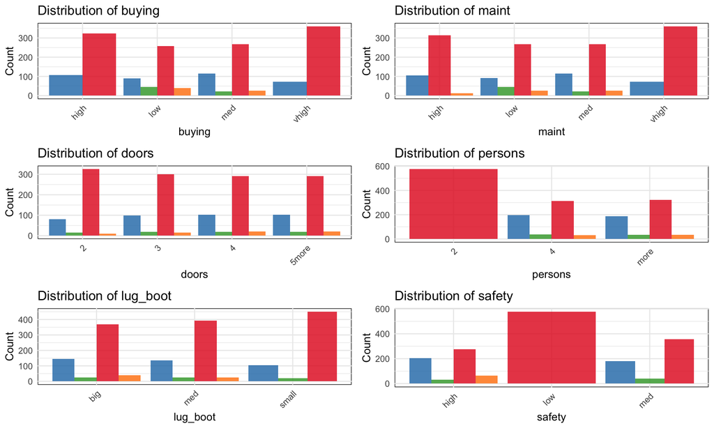

```r
# Create bar plots for each feature
feature_cols <- c('buying', 'maint', 'doors', 'persons', 'lug_boot', 'safety')

plots <- list()
for (i in seq_along(feature_cols)) {
  col_name <- feature_cols[i]
  plots[[i]] <- ggplot(cars_data, aes_string(x = col_name, fill = "class")) +
    geom_bar(position = "dodge", alpha = 0.8) +
    scale_fill_manual(values = c("unacc" = "#e31a1c", "acc" = "#1f78b4",
                                "good" = "#33a02c", "vgood" = "#ff7f00")) +
    labs(title = paste("Distribution of", col_name), x = col_name, y = "Count") +
    theme_minimal() +
    theme(panel.background = element_rect(fill = "white"),
          axis.text.x = element_text(angle = 45, hjust = 1),
          legend.position = "none")
}

# Arrange plots in a grid
do.call(grid.arrange, c(plots, ncol = 2))
```

## Class Distribution by Safety Level

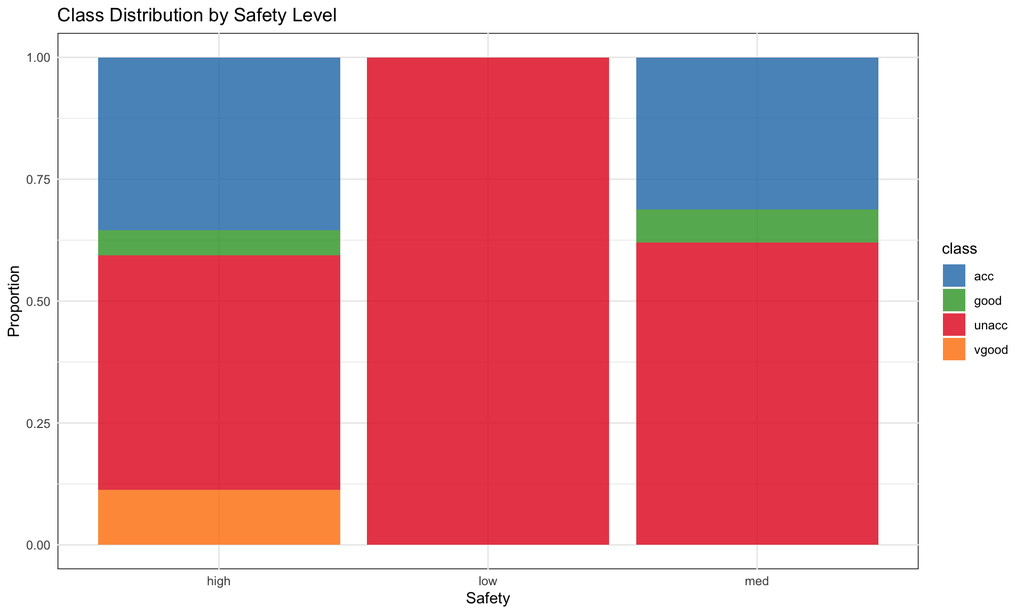

```r
# Class distribution by safety level
ggplot(cars_data, aes(x = safety, fill = class)) +
  geom_bar(position = "fill", alpha = 0.8) +
  scale_fill_manual(values = c("unacc" = "#e31a1c", "acc" = "#1f78b4",
                              "good" = "#33a02c", "vgood" = "#ff7f00")) +
  labs(title = "Class Distribution by Safety Level", x = "Safety", y = "Proportion") +
  theme_minimal() +
  theme(panel.background = element_rect(fill = "white"))
```

# Model Training

## Data Splitting

```r
# Split data into training and test sets (70/30)
train_idx <- createDataPartition(cars_data$class, p = 0.7, list = FALSE)
train_data <- cars_data[train_idx, ]
test_data <- cars_data[-train_idx, ]

cat("Training set size:", nrow(train_data), "\n")
```

```
## Training set size: 1211
```

```r
cat("Test set size:", nrow(test_data), "\n")
```

```
## Test set size: 517
```

## Decision Tree with Gini Criterion

```r
# Train Decision Tree with Gini criterion
dt_gini <- rpart(class ~ ., data = train_data, method = "class",
                 parms = list(split = "gini"))

# Make predictions
pred_gini_train <- predict(dt_gini, train_data, type = "class")
pred_gini_test <- predict(dt_gini, test_data, type = "class")

# Calculate accuracies
acc_gini_train <- mean(pred_gini_train == train_data$class)
acc_gini_test <- mean(pred_gini_test == test_data$class)

cat("Gini Model - Training Accuracy:", round(acc_gini_train, 4), "\n")
```

```
## Gini Model - Training Accuracy: 0.948
```

```r
cat("Gini Model - Test Accuracy:", round(acc_gini_test, 4), "\n")
```

```
## Gini Model - Test Accuracy: 0.9342
```

## Decision Tree with Information Gain

```r
# Train Decision Tree with Information Gain (entropy)
dt_entropy <- rpart(class ~ ., data = train_data, method = "class",
                    parms = list(split = "information"))

# Make predictions
pred_entropy_train <- predict(dt_entropy, train_data, type = "class")
pred_entropy_test <- predict(dt_entropy, test_data, type = "class")

# Calculate accuracies
acc_entropy_train <- mean(pred_entropy_train == train_data$class)
acc_entropy_test <- mean(pred_entropy_test == test_data$class)

cat("Entropy Model - Training Accuracy:", round(acc_entropy_train, 4), "\n")
```

```
## Entropy Model - Training Accuracy: 0.948
```

```r
cat("Entropy Model - Test Accuracy:", round(acc_entropy_test, 4), "\n")
```

```
## Entropy Model - Test Accuracy: 0.9342
```

# Model Visualization

## Decision Tree Plots

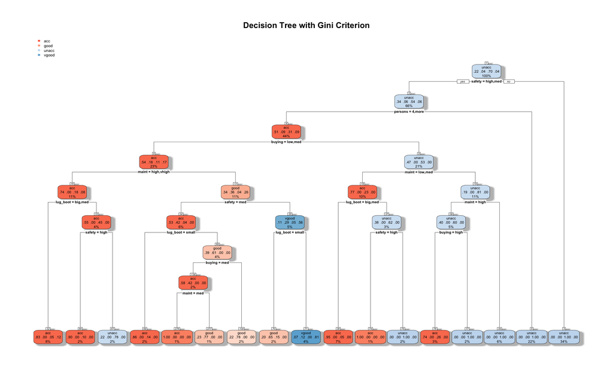

```r
# Plot Gini tree
rpart.plot(dt_gini, main = "Decision Tree with Gini Criterion",
           box.palette = "RdBu", shadow.col = "gray", nn = TRUE)
```

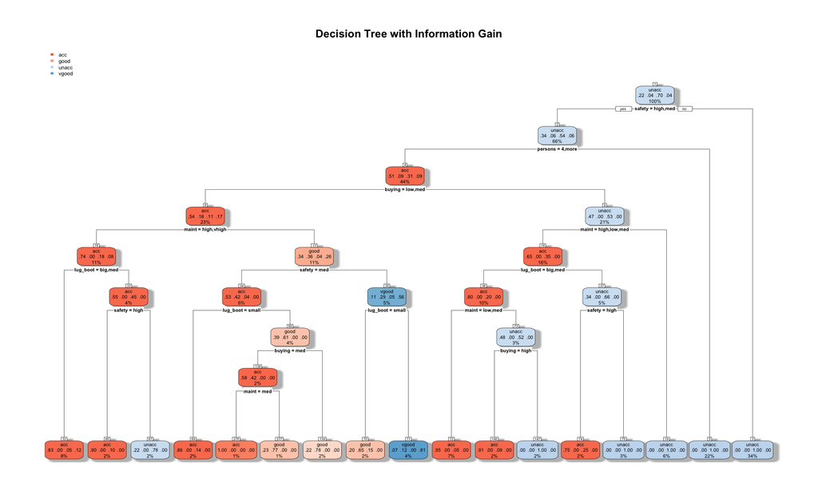

```r
# Plot Entropy tree
rpart.plot(dt_entropy, main = "Decision Tree with Information Gain",
           box.palette = "RdBu", shadow.col = "gray", nn = TRUE)
```

## Feature Importance

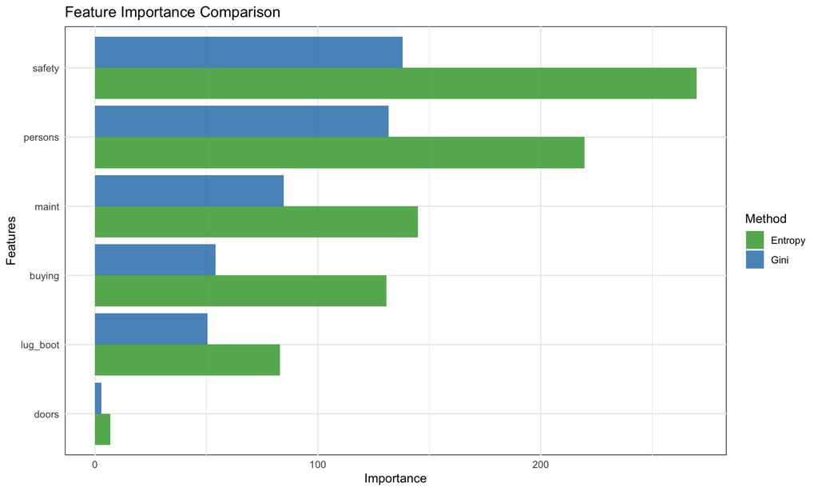

```r
# Extract variable importance
importance_gini <- dt_gini$variable.importance
importance_entropy <- dt_entropy$variable.importance

# Create data frames for plotting
imp_gini_df <- data.frame(
  Feature = names(importance_gini),
  Importance = as.numeric(importance_gini),
  Method = "Gini"
)

imp_entropy_df <- data.frame(
  Feature = names(importance_entropy),
  Importance = as.numeric(importance_entropy),
  Method = "Entropy"
)

# Combine and plot
imp_combined <- rbind(imp_gini_df, imp_entropy_df)

ggplot(imp_combined, aes(x = reorder(Feature, Importance), y = Importance, fill = Method)) +
  geom_bar(stat = "identity", position = "dodge", alpha = 0.8) +
  coord_flip() +
  scale_fill_manual(values = c("Gini" = "#1f78b4", "Entropy" = "#33a02c")) +
  labs(title = "Feature Importance Comparison", x = "Features", y = "Importance") +
  theme_minimal() +
  theme(panel.background = element_rect(fill = "white"))
```

# Model Evaluation

## Confusion Matrices

```r
# Gini confusion matrix
cm_gini <- confusionMatrix(pred_gini_test, test_data$class)
print("Gini Model Confusion Matrix:")
```

```
## [1] "Gini Model Confusion Matrix:"
```

```r
print(cm_gini)
```

```
## Confusion Matrix and Statistics
##
##           Reference
## Prediction acc good unacc vgood
##      acc   110    0    22     2
##      good    3   16     1     0
##      unacc   2    0   340     0
##      vgood   0    4     0    17
##
## Overall Statistics
##
##                Accuracy : 0.9342
##                  95% CI : (0.9093, 0.954)
##     No Information Rate : 0.7021
##     P-Value [Acc > NIR] : < 2.2e-16
##
##                   Kappa : 0.8615
##
##  Mcnemar's Test P-Value : NA
##
## Statistics by Class:
##
##                      Class: acc Class: good Class: unacc Class: vgood
## Sensitivity              0.9565     0.80000       0.9366      0.89474
## Specificity              0.9403     0.99195       0.9870      0.99197
## Pos Pred Value           0.8209     0.80000       0.9942      0.80952
## Neg Pred Value           0.9869     0.99195       0.8686      0.99597
## Prevalence               0.2224     0.03868       0.7021      0.03675
## Detection Rate           0.2128     0.03095       0.6576      0.03288
## Detection Prevalence     0.2592     0.03868       0.6615      0.04062
## Balanced Accuracy        0.9484     0.89598       0.9618      0.94335
```

```r
# Entropy confusion matrix
cm_entropy <- confusionMatrix(pred_entropy_test, test_data$class)
print("\nEntropy Model Confusion Matrix:")
```

```
## [1] "\nEntropy Model Confusion Matrix:"
```

```r
print(cm_entropy)
```

```
## Confusion Matrix and Statistics
##
##           Reference
## Prediction acc good unacc vgood
##      acc   110    0    22     2
##      good    3   16     1     0
##      unacc   2    0   340     0
##      vgood   0    4     0    17
##
## Overall Statistics
##
##                Accuracy : 0.9342
##                  95% CI : (0.9093, 0.954)
##     No Information Rate : 0.7021
##     P-Value [Acc > NIR] : < 2.2e-16
##
##                   Kappa : 0.8615
##
##  Mcnemar's Test P-Value : NA
##
## Statistics by Class:
##
##                      Class: acc Class: good Class: unacc Class: vgood
## Sensitivity              0.9565     0.80000       0.9366      0.89474
## Specificity              0.9403     0.99195       0.9870      0.99197
## Pos Pred Value           0.8209     0.80000       0.9942      0.80952
## Neg Pred Value           0.9869     0.99195       0.8686      0.99597
## Prevalence               0.2224     0.03868       0.7021      0.03675
## Detection Rate           0.2128     0.03095       0.6576      0.03288
## Detection Prevalence     0.2592     0.03868       0.6615      0.04062
## Balanced Accuracy        0.9484     0.89598       0.9618      0.94335
```

## Model Comparison

```r
# Create comparison table
comparison <- data.frame(
  Model = c("Gini", "Entropy"),
  Train_Accuracy = c(acc_gini_train, acc_entropy_train),
  Test_Accuracy = c(acc_gini_test, acc_entropy_test)
)

print("Model Performance Comparison:")
```

```
## [1] "Model Performance Comparison:"
```

```r
print(comparison)
```

```
##     Model Train_Accuracy Test_Accuracy
## 1    Gini      0.9479769      0.934236
## 2 Entropy      0.9479769      0.934236
```

# Results and Conclusion

## Model Summary

```r
# Print model summaries
cat("=== Gini Model Summary ===\n")
```

```
## === Gini Model Summary ===
```

```r
print(summary(dt_gini))
```

```
## Call:
## rpart(formula = class ~ ., data = train_data, method = "class",
##     parms = list(split = "gini"))
##   n= 1211
##
##            CP nsplit rel error    xerror       xstd
## 1  0.14010989      0 1.0000000 1.0000000 0.04383479
## 2  0.11263736      2 0.7197802 0.7912088 0.04070274
## 3  0.03846154      4 0.4945055 0.5192308 0.03469628
## 4  0.03571429      6 0.4175824 0.4560440 0.03288052
## 5  0.03296703      7 0.3818681 0.4093407 0.03140378
## 6  0.03021978      9 0.3159341 0.3763736 0.03028231
## 7  0.02335165     10 0.2857143 0.3406593 0.02898359
## 8  0.01785714     12 0.2390110 0.2857143 0.02678656
## 9  0.01510989     14 0.2032967 0.2609890 0.02570517
## 10 0.01000000     16 0.1730769 0.2252747 0.02402041
##
## Variable importance
##   safety  persons    maint   buying lug_boot    doors
##       30       29       18       12       11        1
##
## Node number 1: 1211 observations,    complexity param=0.1401099
##   predicted class=unacc  expected loss=0.300578  P(node) =1
##     class counts:   269    49   847    46
##    probabilities: 0.222 0.040 0.699 0.038
##   left son=2 (794 obs) right son=3 (417 obs)
##   Primary splits:
##       safety   splits as  LRL,  improve=90.801740, (0 missing)
##       persons  splits as  RLL,  improve=88.171360, (0 missing)
##       buying   splits as  RLLR, improve=16.667720, (0 missing)
##       maint    splits as  LLLR, improve=10.253080, (0 missing)
##       lug_boot splits as  LLR,  improve= 8.987569, (0 missing)
##
## Node number 2: 794 observations,    complexity param=0.1401099
##   predicted class=unacc  expected loss=0.4584383  P(node) =0.6556565
##     class counts:   269    49   430    46
##    probabilities: 0.339 0.062 0.542 0.058
##   left son=4 (531 obs) right son=5 (263 obs)
##   Primary splits:
##       persons  splits as  RLL,  improve=130.606100, (0 missing)
```

[output cut: 309 more lines]

```
##              70) lug_boot=small 20   7 good (0.20000000 0.65000000 0.15000000 0.00000000) *
##              71) lug_boot=big,med 43   8 vgood (0.06976744 0.11627907 0.00000000 0.81395349) *
##         9) buying=high,vhigh 258 122 unacc (0.47286822 0.00000000 0.52713178 0.00000000)
##          18) maint=low,med 124  28 acc (0.77419355 0.00000000 0.22580645 0.00000000)
##            36) lug_boot=big,med 85   4 acc (0.95294118 0.00000000 0.04705882 0.00000000) *
##            37) lug_boot=small 39  15 unacc (0.38461538 0.00000000 0.61538462 0.00000000)
##              74) safety=high 15   0 acc (1.00000000 0.00000000 0.00000000 0.00000000) *
##              75) safety=med 24   0 unacc (0.00000000 0.00000000 1.00000000 0.00000000) *
##          19) maint=high,vhigh 134  26 unacc (0.19402985 0.00000000 0.80597015 0.00000000)
##            38) maint=high 65  26 unacc (0.40000000 0.00000000 0.60000000 0.00000000)
##              76) buying=high 35   9 acc (0.74285714 0.00000000 0.25714286 0.00000000) *
##              77) buying=vhigh 30   0 unacc (0.00000000 0.00000000 1.00000000 0.00000000) *
##            39) maint=vhigh 69   0 unacc (0.00000000 0.00000000 1.00000000 0.00000000) *
##       5) persons=2 263   0 unacc (0.00000000 0.00000000 1.00000000 0.00000000) *
##     3) safety=low 417   0 unacc (0.00000000 0.00000000 1.00000000 0.00000000) *
```

```r
cat("\n=== Entropy Model Summary ===\n")
```

```
##
## === Entropy Model Summary ===
```

```r
print(summary(dt_entropy))
```

```
## Call:
## rpart(formula = class ~ ., data = train_data, method = "class",
##     parms = list(split = "information"))
##   n= 1211
##
##            CP nsplit rel error    xerror       xstd
## 1  0.14010989      0 1.0000000 1.0000000 0.04383479
## 2  0.09478022      2 0.7197802 0.7197802 0.03936500
## 3  0.05494505      4 0.5302198 0.5302198 0.03499283
## 4  0.03846154      5 0.4752747 0.5027473 0.03424117
## 5  0.03571429      8 0.3598901 0.4752747 0.03345402
## 6  0.03021978      9 0.3241758 0.3763736 0.03028231
## 7  0.02747253     10 0.2939560 0.3379121 0.02887976
## 8  0.01785714     12 0.2390110 0.2939560 0.02713332
## 9  0.01510989     14 0.2032967 0.2307692 0.02429004
## 10 0.01000000     16 0.1730769 0.2005495 0.02275407
##
## Variable importance
##   safety  persons    maint   buying lug_boot    doors
##       32       26       17       15       10        1
##
## Node number 1: 1211 observations,    complexity param=0.1401099
##   predicted class=unacc  expected loss=0.300578  P(node) =1
##     class counts:   269    49   847    46
##    probabilities: 0.222 0.040 0.699 0.038
##   left son=2 (794 obs) right son=3 (417 obs)
##   Primary splits:
##       safety   splits as  LRL,  improve=192.73620, (0 missing)
##       persons  splits as  RLL,  improve=187.86360, (0 missing)
##       buying   splits as  RLLR, improve= 76.54939, (0 missing)
##       maint    splits as  RLLR, improve= 47.81492, (0 missing)
##       lug_boot splits as  LLR,  improve= 28.01635, (0 missing)
##
## Node number 2: 794 observations,    complexity param=0.1401099
##   predicted class=unacc  expected loss=0.4584383  P(node) =0.6556565
##     class counts:   269    49   430    46
##    probabilities: 0.339 0.062 0.542 0.058
##   left son=4 (531 obs) right son=5 (263 obs)
##   Primary splits:
##       persons  splits as  RLL,  improve=216.98300, (0 missing)
```

[output cut: 307 more lines]

```
##              70) lug_boot=small 20   7 good (0.20000000 0.65000000 0.15000000 0.00000000) *
##              71) lug_boot=big,med 43   8 vgood (0.06976744 0.11627907 0.00000000 0.81395349) *
##         9) buying=high,vhigh 258 122 unacc (0.47286822 0.00000000 0.52713178 0.00000000)
##          18) maint=high,low,med 189  67 acc (0.64550265 0.00000000 0.35449735 0.00000000)
##            36) lug_boot=big,med 127  26 acc (0.79527559 0.00000000 0.20472441 0.00000000)
##              72) maint=low,med 85   4 acc (0.95294118 0.00000000 0.04705882 0.00000000) *
##              73) maint=high 42  20 unacc (0.47619048 0.00000000 0.52380952 0.00000000)
##               146) buying=high 22   2 acc (0.90909091 0.00000000 0.09090909 0.00000000) *
##               147) buying=vhigh 20   0 unacc (0.00000000 0.00000000 1.00000000 0.00000000) *
##            37) lug_boot=small 62  21 unacc (0.33870968 0.00000000 0.66129032 0.00000000)
##              74) safety=high 28   7 acc (0.75000000 0.00000000 0.25000000 0.00000000) *
##              75) safety=med 34   0 unacc (0.00000000 0.00000000 1.00000000 0.00000000) *
##          19) maint=vhigh 69   0 unacc (0.00000000 0.00000000 1.00000000 0.00000000) *
##       5) persons=2 263   0 unacc (0.00000000 0.00000000 1.00000000 0.00000000) *
##     3) safety=low 417   0 unacc (0.00000000 0.00000000 1.00000000 0.00000000) *
```

## Recommendations

1. **Feature Engineering**: Consider creating interaction features between safety and price-related variables.
2. **Model Tuning**: Experiment with different pruning parameters to optimize model complexity.
3. **Ensemble Methods**: Consider using Random Forest or Gradient Boosting for potentially better performance.
4. **Cross-Validation**: Implement k-fold cross-validation for more robust performance estimation.

The Decision Tree models successfully classify car acceptability with good accuracy, providing interpretable rules for decision-making in car evaluation scenarios.